# Аналитика на сайте (плюс первая статья)

## ВАЖНЫЕ ЗАМЕЧАНИЯ

> В документе всё постоено на `full_data_precise_original`. Никаких манипуляций с данным не произведено. Если исследовательская область выглядит как список, например, `Political Science; Area Studies`, тогда публикация дублируется и считатся как +1 публикация для каждой из областей в списке. Фракционализация проводилась только для институций в разделе I, пункте (8) (показаны таблицы и с фракционализацией и без).

## I. PRODUCTION OF PUBLICATIONS

#### (1) График динамики, на котором также виден прирост в % (вторая шкала). Типа такого. Два графика: один для социальных наук, один для гуманитарных.

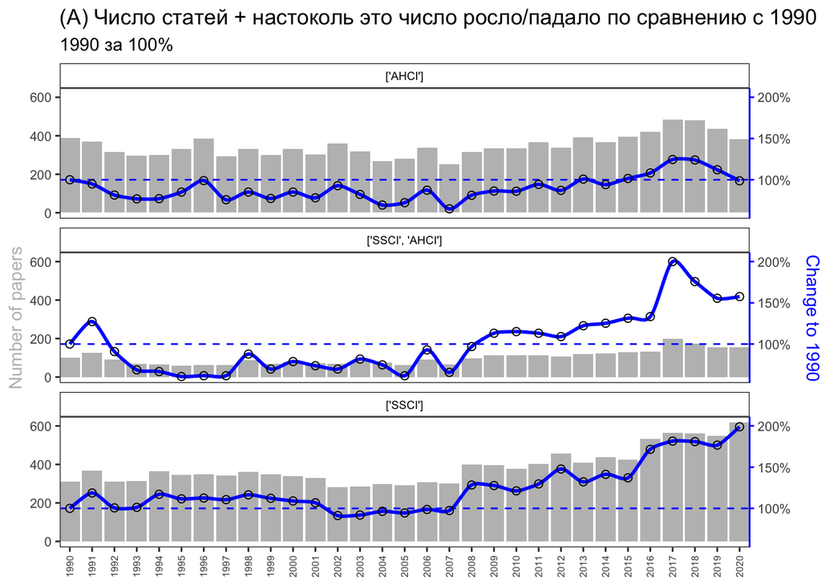

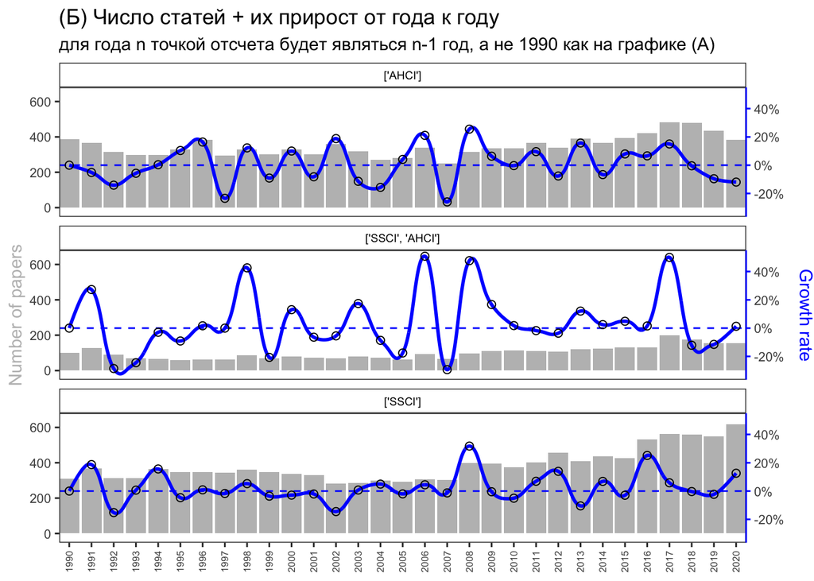

#### (2) График динамики по областям. Отдельно график, на котором тренд увеличивающийся. Отдельно, на котором уменьшающийся тренд. Отдельно в долях от всех публикаций за год и отдельно в статьях.

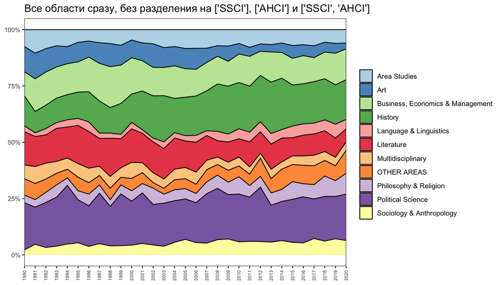

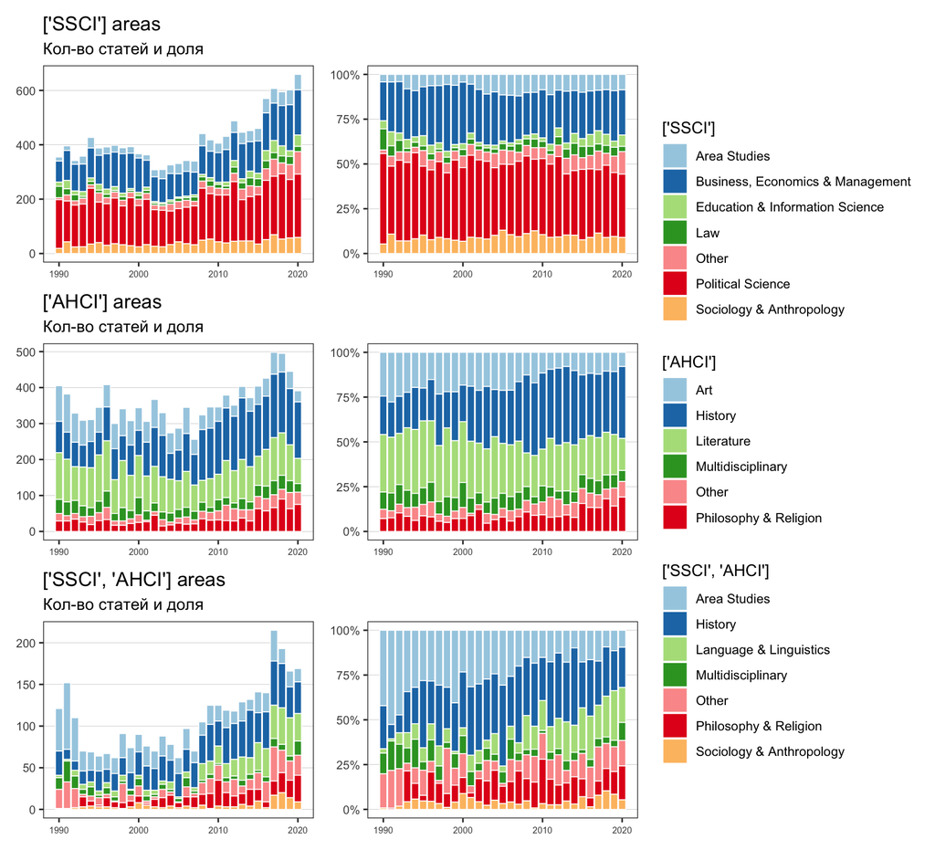

#### (2а) Число статей по областям (15 областей), и их принадлежность к AHCI и SSCI

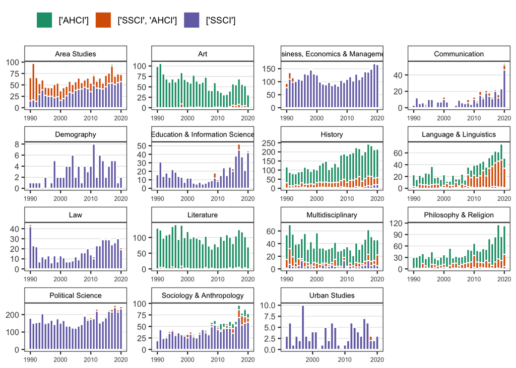

#### (3) График динамики по регионам по годам (регионы, возможно надо перепроверить классификацию). В числах и долях.

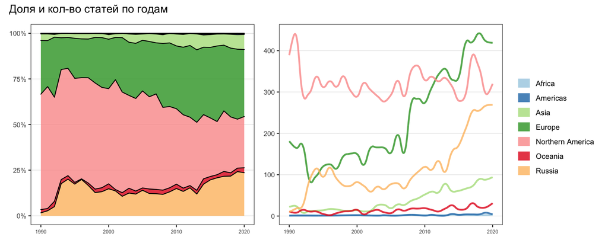

#### (4) Специализация регионов. На каких областях специализируются отдельные регионы. Просто серия графиков для каждого региона с горизонтальной гистограммой-области (15 областей наших), показана доля.

Убираем `Africa`, `Americas`, `Oceania`

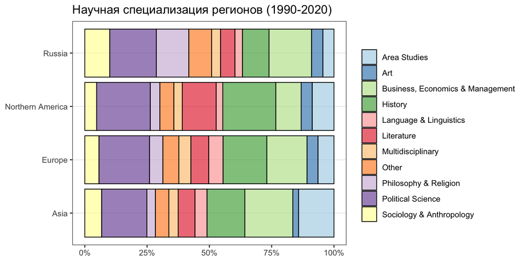

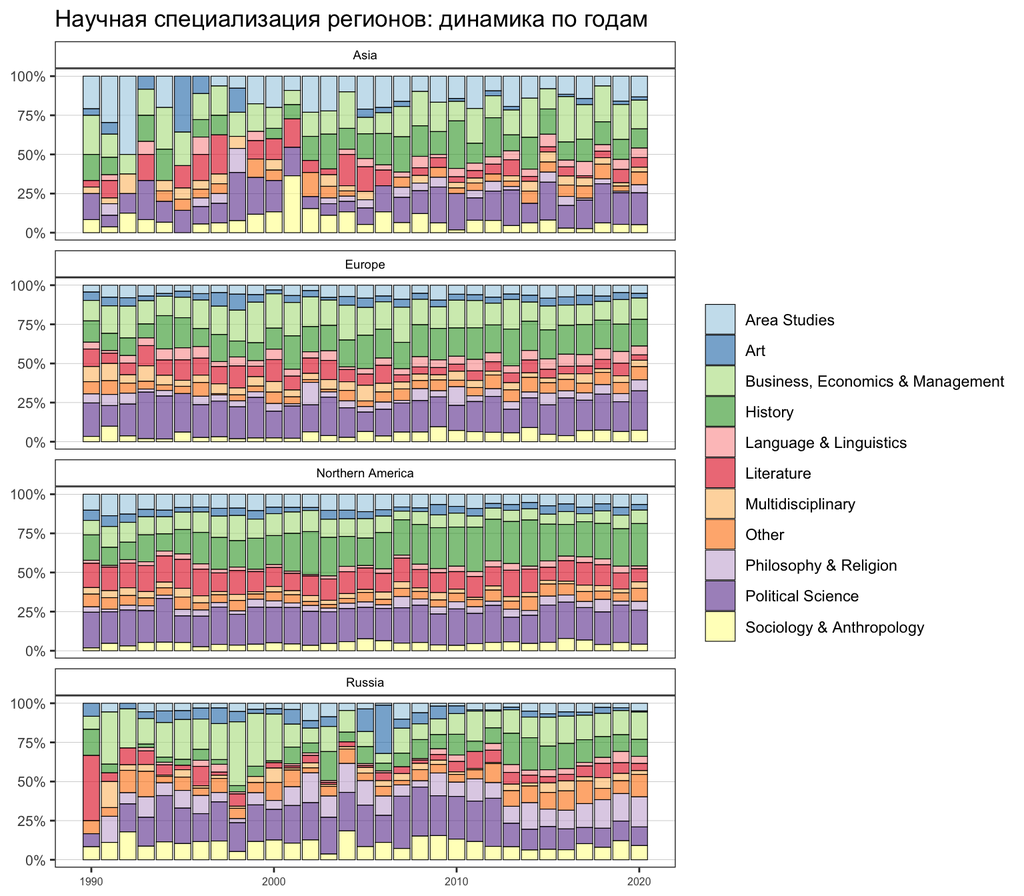

#### (5) Специализация областей. И наоборот: это один график с горизонтальной гистограммой-области (15 областей наших), показана доля регионов для области.

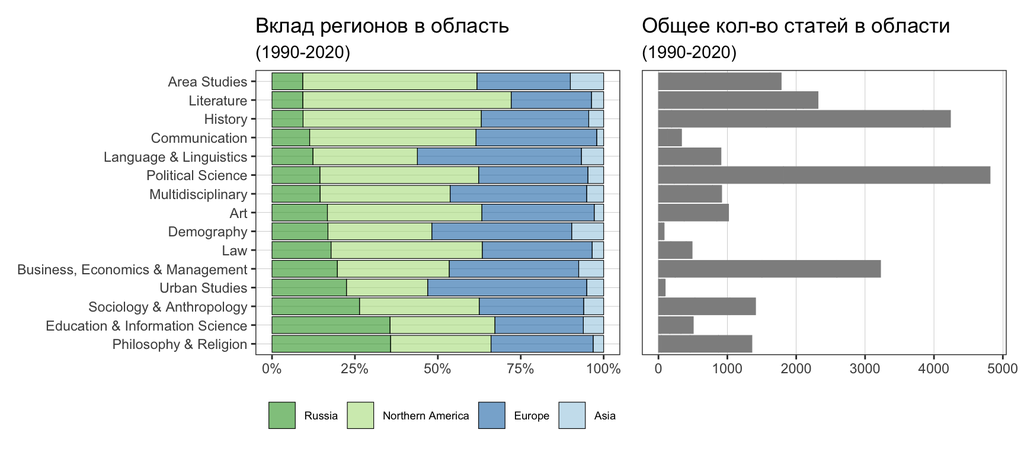

#### (6) Страны и динамика – это уже делал Сергей.

#### (7) Страны и организации 1. Можно взять 15 стран с наибольшим вкладом. И сделать таблицы: количество организаций в периоды (наши 3 периода), интересно также увидеть количество новых организаций в каждом периоде (как бы прирост).

| country | 1990-2000 | 2001-2010 | growth_to_first_period(%) | 2011-2020 | growth_to_sec_period(%) |
| --- | --- | --- | --- | --- | --- |
| Usa | 357 | 370 | 3.6 | 469 | 26.8 |
| Russia | 77 | 100 | 29.9 | 234 | 134 |
| England | 69 | 82 | 18.8 | 127 | 54.9 |
| Germany | 30 | 56 | 86.7 | 115 | 105.4 |
| France | 11 | 17 | 54.5 | 56 | 229.4 |
| Peoples R China | 5 | 12 | 140 | 56 | 366.7 |
| Canada | 29 | 34 | 17.2 | 41 | 20.6 |
| Italy | 9 | 12 | 33.3 | 41 | 241.7 |
| Turkey | 2 | 11 | 450 | 36 | 227.3 |
| Australia | 19 | 19 | 0 | 34 | 78.9 |

[output cut: 78 more lines]

#### (8) Страны и организации 2. Можно взять 15 стран с наибольшим вкладом. И сделать таблицы как ниже, но только с most contributing countries и most contributing institutions но для три периода.

Примечание: Из 33937 строк у ~8100 нет институции и у ~4200 нет страны

##### A. Most contributing countries

| country | 1990-2000 | (%) 1990-2000 | 2001-2010 | (%) 2001-2010 | 2011-2020 | (%) 2011-2020 |
| --- | --- | --- | --- | --- | --- | --- |
| Usa | 3839 | 39.43 | 3549 | 39.22 | 3828 | 25.27 |
| Russia | 1005 | 10.32 | 1024 | 11.31 | 3148 | 20.78 |
| England | 811 | 8.33 | 998 | 11.03 | 1509 | 9.96 |
| OTHER | 133 | 1.37 | 223 | 2.46 | 942 | 6.22 |
| Germany | 131 | 1.35 | 263 | 2.91 | 707 | 4.67 |
| Unknown | 2562 | 26.31 | 1126 | 12.44 | 575 | 3.8 |
| Finland | 37 | 0.38 | 157 | 1.73 | 467 | 3.08 |
| Canada | 268 | 2.75 | 270 | 2.98 | 388 | 2.56 |
| Peoples R China | 6 | 0.06 | 32 | 0.35 | 277 | 1.83 |
| Norway | 35 | 0.36 | 115 | 1.27 | 273 | 1.8 |

[output cut: 21 more lines]

##### B. Most contributing institutions

###### Без франкционализации

| organisation_full | 1990-2000 | (%) 1990-2000 | 2001-2010 | (%) 2001-2010 | 2011-2020 | (%) 2011-2020 |
| --- | --- | --- | --- | --- | --- | --- |
| Unknown | 3644 | 37.42 | 2391 | 26.42 | 2158 | 14.24 |
| OTHER (&lt; 5 pub 1990-2020) | 257 | 2.64 | 347 | 3.83 | 1431 | 9.45 |
| National Research University Higher Sch Econ | 23 | 0.24 | 54 | 0.6 | 1002 | 6.61 |
| Russian Academy of Sciences | 463 | 4.76 | 289 | 3.19 | 494 | 3.26 |
| Saint Petersburg State University | 26 | 0.27 | 75 | 0.83 | 198 | 1.31 |
| University of Tartu | 8 | 0.08 | 40 | 0.44 | 160 | 1.06 |
| University of Oxford | 60 | 0.62 | 106 | 1.17 | 143 | 0.94 |
| University of Helsinki | 10 | 0.1 | 35 | 0.39 | 109 | 0.72 |
| Harvard University | 188 | 1.93 | 119 | 1.31 | 107 | 0.71 |
| University of Wisconsin | 91 | 0.93 | 74 | 0.82 | 104 | 0.69 |

[output cut: 836 more lines]

###### Франкционализация

| organisation_full | 1990-2000 | (%) 1990-2000 | 2001-2010 | (%) 2001-2010 | 2011-2020 | (%) 2011-2020 |
| --- | --- | --- | --- | --- | --- | --- |
| Unknown | 3069.48 | 37.19 | 1912.06 | 26.52 | 1553.04 | 14.91 |
| National Research University Higher Sch Econ | 12.32 | 0.15 | 35.65 | 0.49 | 573.24 | 5.5 |
| Russian Academy of Sciences | 363.95 | 4.41 | 214.55 | 2.98 | 342.67 | 3.29 |
| University of Oxford | 54.58 | 0.66 | 92.67 | 1.29 | 120.15 | 1.15 |
| Saint Petersburg State University | 22.42 | 0.27 | 66.36 | 0.92 | 114.78 | 1.1 |
| University of Tartu | 8 | 0.1 | 26.53 | 0.37 | 96.43 | 0.93 |
| Harvard University | 164.57 | 1.99 | 104.82 | 1.45 | 86.62 | 0.83 |
| University College London | 5.5 | 0.07 | 43.95 | 0.61 | 76.95 | 0.74 |
| University of Helsinki | 9.5 | 0.12 | 27.67 | 0.38 | 75.07 | 0.72 |
| University of Cambridge | 58.67 | 0.71 | 53.42 | 0.74 | 73.33 | 0.7 |

[output cut: 1919 more lines]

##### Метод фракционализации:

> Пусть статью написало 3 человека из институции А. Тогда институции А приписывается 1 статья. Пусть статью написало 3 человека, причем один из институции А и двое из институции В. Тогда институции А приписывается 0.33 статьи, а институции В 0.66 статьи.

Техническое решение для фракционализации по описанию Анжелики:

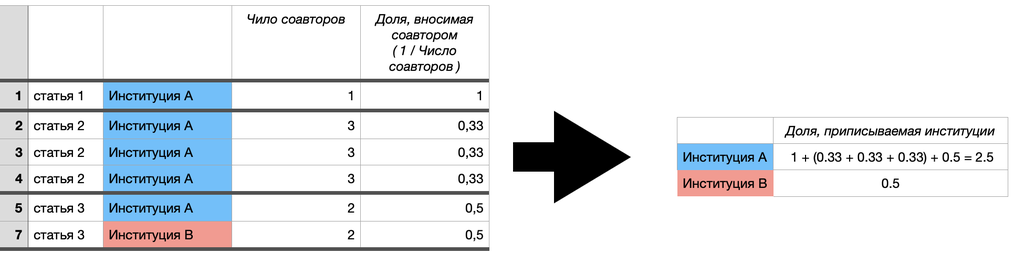

#### (9) Организации и динамика их вклада. Взять наш топ организаций и показать, как по периодам (у нас их три) распределяются статьи.

Это не **most contributing institutions** из предыдущего пункта? Но в этом пункте в таблице из примера около институции подписана страна. В нашем это не оч хорошо показывать, так как грязные данные местами. Если показываю столбец со страной вот так будет:

| organisation_full | count | country |
| --- | --- | --- |
| Unknown | 8193 | Argentina; Armenia; Australia; Austria; Azerbaijan; Belarus; Belgium; Bosnia And Herzegovina; Brazil; Brunei; Bulgaria; Cambodia; Canada; Chile; Colombia; Croatia; Cyprus; Czech Republic; Denmark; Eng… |
| OTHER (&lt; 5 pub 1990-2020) | 2035 | Argentina; Armenia; Australia; Austria; Azerbaijan; Belarus; Belgium; Brazil; Brunei; Bulgaria; Canada; Chile; Colombia; Croatia; Cyprus; Czech Republic; Denmark; Ecuador; England; Estonia; Finland; F… |
| Russian Academy of Sciences | 1246 | Canada; Estonia; Hungary; Peoples R China; Russia; Taiwan; Unknown; Ussr |
| National Research University Higher Sch Econ | 1079 | England; Russia; Unknown |
| Harvard University | 414 | England; Usa |
| University of Oxford | 309 | England |
| Saint Petersburg State University | 299 | Russia; Usa; Ussr |
| University of Wisconsin | 269 | Russia; Usa |
| University of Michigan | 259 | Usa |
| University of California Berkeley | 250 | Unknown; Usa |

[output cut: 836 more lines]

## II. IMPACT OF PIBLICATIONS

#### (1) Средние значения показателей импакта (MNSC, средняя цитируемость на статью – это все разные графики) по годам для регионов.

#### (2) Страны и динамика их цитируемости. Таблица с основными странами, разделение на 3 периода и следующие показатели в каждом периоде показать: кол-во публикаций, MNSC, средняя цитируемость на статью.

#### (3) Средние значения показателей вхождения в топ по годам для регионов на отдельных графиках – доли статей в топе 1, 10 и 25. Три графика – линии это для регионов.

#### (4) Страны и динамика их импакта по вхождению в топ. Таблица с основными странами, разделение на 3 периода и следующие показатели в каждом периоде показать: кол-во публикаций, кол-во статей в топе 1, 10 и 25 (в скобках доли статей в топе).

#### (5) Средние значения показателей по группам институций в динамике: 5,10,20 лучших, все остальные. Показатели MNSC, средняя цитируемость на статью. Линиями на графиках, а группы – это 5,10,20 лучших.

#### (6) Взять только 25% самых цитируемых публикаций в SSCI и в AHCI по отдельности в каждый из годов. График с долями регионов в самом цитируемом аутпуте разными линиями. Фракционализировать по странам. Подумать, как наглядно такое показать для стран?

#### (7) Взять только статьи в журналах 1 квартиля в каждый из год (только с 2000 года период). Показать доли регионов по годам разными линиями. Фракционализировать по странам. Подумать, как наглядно такое показать для стран?